# Inferencia estadística II

El bootstrap

Autor/a

Alejandro Veloz

Este apunte sigue el capítulo 8 de Wasserman. El bootstrap es un método para estimar errores estándar y construir intervalos de confianza cuando no existe una fórmula, y es la herramienta que resuelve el problema con que cerró el apunte I.

# 1 La idea

Sea $T_n = g(X_1, \ldots, X_n)$ un estadístico cualquiera. Queremos $\mathbb{V}_F(T_n)$, la varianza de $T_n$, que en general depende de la distribución desconocida $F$. Por ejemplo, si $T_n = \bar X_n$ entonces $\mathbb{V}_F(T_n) = \sigma^2/n$ con $\sigma^2 = \int (x - \mu)^2\,dF(x)$. El bootstrap tiene dos pasos.

1. Estimar $\mathbb{V}_F(T_n)$ con $\mathbb{V}_{\hat F_n}(T_n)$, es decir, sustituir $F$ por la distribución empírica.
2. Aproximar $\mathbb{V}_{\hat F_n}(T_n)$ por simulación.

Para $\bar X_n$ el primer paso basta, porque $\mathbb{V}_{\hat F_n}(\bar X_n) = \hat\sigma^2/n$ tiene forma cerrada. En casos más complicados no se puede escribir $\mathbb{V}_{\hat F_n}(T_n)$ y hace falta el segundo paso.

El segundo paso se apoya en la ley de los grandes números. Si $Y_1, \ldots, Y_B$ es una muestra iid de una distribución $G$, entonces $B^{-1}\sum_j h(Y_j) \xrightarrow{P} \mathbb{E}(h(Y))$ cuando $B \to \infty$, y en particular la varianza muestral de los $Y_j$ aproxima $\mathbb{V}(Y)$. En una simulación $B$ se puede hacer tan grande como se quiera.

¿Cómo se simula de la distribución de $T_n$ cuando los datos tienen distribución $\hat F_n$? Se simula $X_1^*, \ldots, X_n^* \sim \hat F_n$ y se calcula $T_n^* = g(X_1^*, \ldots, X_n^*)$. Como $\hat F_n$ asigna masa $1/n$ a cada dato, extraer una observación de $\hat F_n$ equivale a extraer un punto al azar del conjunto de datos original. Simular $X_1^*, \ldots, X_n^* \sim \hat F_n$ es lo mismo que extraer $n$ observaciones **con reemplazo** de $X_1, \ldots, X_n$.

$$\begin{array}{lccccc}
\text{Mundo real} & F & \Longrightarrow & X_1, \ldots, X_n & \Longrightarrow & T_n = g(X_1, \ldots, X_n) \\
\text{Mundo bootstrap} & \hat F_n & \Longrightarrow & X_1^*, \ldots, X_n^* & \Longrightarrow & T_n^* = g(X_1^*, \ldots, X_n^*)
\end{array}$$

# 2 Estimación bootstrap de la varianza

El algoritmo es el siguiente.

1. Extraer $X_1^*, \ldots, X_n^* \sim \hat F_n$ (muestreo con reemplazo de los datos).
2. Calcular $T_n^* = g(X_1^*, \ldots, X_n^*)$.
3. Repetir los pasos 1 y 2 $B$ veces, obteniendo $T_{n,1}^*, \ldots, T_{n,B}^*$.
4. Calcular
   $$v_{\text{boot}} = \frac{1}{B}\sum_{b=1}^B \Big(T_{n,b}^* - \frac1B\sum_{r=1}^B T_{n,r}^*\Big)^2.$$

El error estándar bootstrap es $\widehat{\operatorname{se}}_{\text{boot}} = \sqrt{v_{\text{boot}}}$. Hay dos aproximaciones encadenadas,
$$\mathbb{V}_F(T_n) \;\overset{\text{no tan pequeña}}{\approx}\; \mathbb{V}_{\hat F_n}(T_n) \;\overset{\text{pequeña}}{\approx}\; v_{\text{boot}}.$$
La segunda se controla aumentando $B$. La primera depende de $n$ y no de $B$; con $n$ pequeño el bootstrap hereda la pobreza de $\hat F_n$ como estimación de $F$.

```python
def bootstrap(x, estadistico, B=2000):
    """Réplicas bootstrap de un estadístico escalar."""
    n = len(x)
    return np.array([estadistico(x[rng.integers(0, n, n)]) for _ in range(B)])

x = rng.lognormal(0, 0.8, 60)
T = np.median(x)
Tb = bootstrap(x, np.median)
print("mediana = %.3f   se_boot = %.3f" % (T, Tb.std()))
```

```
mediana = 0.967   se_boot = 0.159
```

En cuatro líneas se obtiene un error estándar para la mediana, cantidad para la cual no existe fórmula cerrada útil. El mismo código sirve para la asimetría, la correlación o cualquier función de los datos.

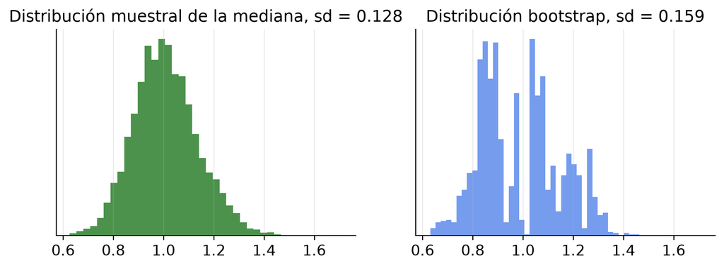

```python
n = 60
verdadera = np.array([np.median(rng.lognormal(0, 0.8, n)) for _ in range(4000)])
fig, ax = plt.subplots(1, 2, figsize=(9.5, 3), sharex=True)
ax[0].hist(verdadera, bins=40, color=MYGREEN, alpha=.7); ax[0].set_title("Distribución muestral de la mediana, sd = %.3f" % verdadera.std())
ax[1].hist(Tb, bins=40, color=MYBLUE, alpha=.7); ax[1].set_title("Distribución bootstrap, sd = %.3f" % Tb.std())
for a in ax: a.set_yticks([])
plt.show()
```

# 3 Intervalos de confianza bootstrap

Hay varias maneras de construir intervalos con las réplicas. Consideremos tres.

**Método 1, intervalo normal.** El más simple es
$$T_n \pm z_{\alpha/2}\,\widehat{\operatorname{se}}_{\text{boot}}.$$
No es preciso salvo que la distribución de $T_n$ sea cercana a la normal.

**Método 2, intervalo pivotal.** Sea $\theta = T(F)$, $\hat\theta_n = T(\hat F_n)$ y el pivote $R_n = \hat\theta_n - \theta$, con función de distribución $H(r) = \mathbb{P}_F(R_n \le r)$. Definamos $a = \hat\theta_n - H^{-1}(1 - \alpha/2)$ y $b = \hat\theta_n - H^{-1}(\alpha/2)$. Entonces
$$\mathbb{P}(a \le \theta \le b) = \mathbb{P}(\hat\theta_n - b \le R_n \le \hat\theta_n - a) = H(H^{-1}(1 - \tfrac\alpha2)) - H(H^{-1}(\tfrac\alpha2)) = 1 - \alpha,$$
de modo que $(a, b)$ es un intervalo exacto. El problema es que $H$ es desconocida, y la estimamos por bootstrap con $\hat H(r) = B^{-1}\sum_b \mathbf{1}\{R_{n,b}^* \le r\}$, donde $R_{n,b}^* = \hat\theta_{n,b}^* - \hat\theta_n$. Si $\theta_\beta^*$ denota el cuantil $\beta$ de las réplicas, resulta
$$C_n = \big(2\hat\theta_n - \theta^*_{1-\alpha/2},\; 2\hat\theta_n - \theta^*_{\alpha/2}\big).$$
Bajo condiciones débiles sobre $T(F)$, $\mathbb{P}_F(T(F) \in C_n) \to 1 - \alpha$.

**Método 3, intervalo de percentiles.** Se toman directamente los cuantiles de las réplicas,
$$C_n = \big(\theta^*_{\alpha/2},\; \theta^*_{1-\alpha/2}\big).$$
Su justificación supone que existe una transformación monótona $m$ tal que $m(T_n)$ es normal; no hace falta conocerla, sólo que exista. Los tres intervalos son aproximados y tienen el mismo orden de precisión. Existen intervalos bootstrap más precisos (BCa, bootstrap-$t$) que no se tratan aquí.

```python
def intervalos_boot(x, estadistico, B=2000, alpha=0.05):
    T = estadistico(x)
    Tb = bootstrap(x, estadistico, B)
    se = Tb.std()
    z = stats.norm.ppf(1 - alpha/2)
    q_lo, q_hi = np.quantile(Tb, [alpha/2, 1 - alpha/2])
    return {"estimación": T, "se": se,
            "normal": (T - z*se, T + z*se),
            "pivotal": (2*T - q_hi, 2*T - q_lo),
            "percentil": (q_lo, q_hi)}

def asimetria(x):
    m = x.mean(); s = np.sqrt(((x - m)**2).mean())
    return ((x - m)**3).mean() / s**3

res = intervalos_boot(x, asimetria)
for k, v in res.items():
    print("%-11s" % k, np.round(v, 3))
```

```
estimación  1.539
se          0.292
normal      [0.967 2.11 ]
pivotal     [0.934 2.076]
percentil   [1.002 2.143]
```

# 4 Verificación de la cobertura

Lo que distingue a un intervalo válido es su cobertura real, y con datos simulados se puede medir. El experimento repite el proceso completo, generar una muestra de $F$, construir los tres intervalos y comprobar si contienen al valor verdadero, muchas veces.

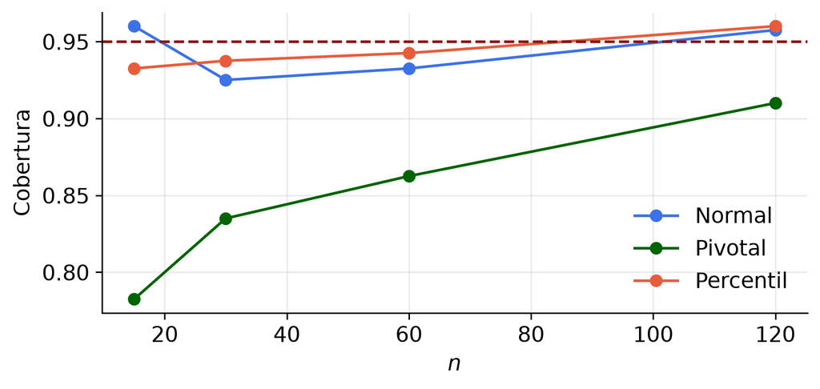

```python
mediana_real = np.exp(0)   # mediana de lognormal(0, s) = 1
def cobertura_boot(n, R=400, B=500):
    hits = np.zeros(3)
    for _ in range(R):
        xs = rng.lognormal(0, 0.8, n)
        r = intervalos_boot(xs, np.median, B)
        for k, key in enumerate(["normal", "pivotal", "percentil"]):
            hits[k] += r[key][0] <= mediana_real <= r[key][1]
    return hits / R

ns = [15, 30, 60, 120]
cob = np.array([cobertura_boot(n) for n in ns])
fig, ax = plt.subplots(figsize=(7, 3))
for k, (key, c) in enumerate(zip(["Normal", "Pivotal", "Percentil"], [MYBLUE, MYGREEN, MYORANGE])):
    ax.plot(ns, cob[:, k], "o-", color=c, label=key)
ax.axhline(0.95, color=MYRED, ls="--"); ax.set_xlabel("$n$"); ax.set_ylabel("Cobertura"); ax.legend(); plt.show()
```

# 5 Ejemplos clásicos

```python
x1 = rng.normal(195, 36, 51); x2 = rng.normal(216, 43, 320)
def dif_medianas_boot(x1, x2, B=2000):
    return np.array([np.median(x2[rng.integers(0, len(x2), len(x2))]) - np.median(x1[rng.integers(0, len(x1), len(x1))]) for _ in range(B)])
Tb = dif_medianas_boot(x1, x2); T = np.median(x2) - np.median(x1)
print("dif. medianas = %.1f   se_boot = %.2f   IC percentil 95 %% = (%.1f, %.1f)" % (T, Tb.std(), *np.quantile(Tb, [.025, .975])))
```

```
dif. medianas = 21.7   se_boot = 12.31   IC percentil 95 % = (-3.6, 38.0)
```

```
r = 0.546   se_boot = 0.195   normal = (0.16, 0.93)   percentil = (0.21, 0.94)
```

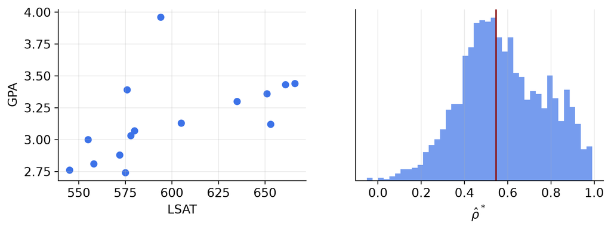

```python
lsat = np.array([576, 635, 558, 578, 666, 580, 555, 661, 651, 605, 653, 575, 545, 572, 594])
gpa  = np.array([3.39, 3.30, 2.81, 3.03, 3.44, 3.07, 3.00, 3.43, 3.36, 3.13, 3.12, 2.74, 2.76, 2.88, 3.96])
n = len(lsat)
rb = np.array([np.corrcoef(lsat[i], gpa[i])[0, 1] for i in (rng.integers(0, n, n) for _ in range(2000))])
r = np.corrcoef(lsat, gpa)[0, 1]
print("r = %.3f   se_boot = %.3f   normal = (%.2f, %.2f)   percentil = (%.2f, %.2f)"
      % (r, rb.std(), r - 1.96*rb.std(), r + 1.96*rb.std(), *np.quantile(rb, [.025, .975])))
fig, ax = plt.subplots(1, 2, figsize=(9.5, 3))
ax[0].scatter(lsat, gpa, color=MYBLUE); ax[0].set_xlabel("LSAT"); ax[0].set_ylabel("GPA")
ax[1].hist(rb, bins=40, color=MYBLUE, alpha=.7); ax[1].axvline(r, color=MYRED); ax[1].set_xlabel("$\\hat\\rho^*$"); ax[1].set_yticks([])
plt.show()
```

**Bioequivalencia.** Ocho sujetos recibieron placebo, un parche antiguo y uno nuevo. Con $Z = $ antiguo $-$ placebo e $Y = $ nuevo $-$ antiguo, el criterio regulatorio de bioequivalencia es $|\theta| \le 0{,}20$ con $\theta = \mathbb{E}(Y)/\mathbb{E}(Z)$. La estimación de sustitución fue $\hat\theta = \bar Y/\bar Z = -0{,}0713$, el error estándar bootstrap $0{,}105$ y el intervalo del 95 %, $(-0{,}24, 0{,}15)$, que no está contenido en $(-0{,}20, 0{,}20)$. Al nivel del 95 % no se demostró la bioequivalencia. Este ejemplo muestra el uso de un intervalo para una decisión regulatoria y el bootstrap para un cociente de medias, cantidad sin fórmula sencilla de error estándar.

# 6 Bootstrap paramétrico

En el bootstrap no paramétrico se remuestrea de $\hat F_n$. Si se supone un modelo paramétrico $f(x;\theta)$, se puede remuestrear de $f(x;\hat\theta_n)$, donde $\hat\theta_n$ es el estimador de máxima verosimilitud o el de momentos del apunte III. El resto del procedimiento es idéntico. El bootstrap paramétrico es más eficiente cuando el modelo es correcto y hereda todo su sesgo cuando no lo es.

```python
x = rng.normal(5, 2, 40)
mu, sd = x.mean(), x.std()
tau = sd / mu                                     # coeficiente de variación
tb_np = bootstrap(x, lambda v: v.std()/v.mean())  # no paramétrico
tb_p  = np.array([(lambda v: v.std()/v.mean())(rng.normal(mu, sd, 40)) for _ in range(2000)])  # paramétrico
print("tau = %.3f   se no paramétrico = %.4f   se paramétrico = %.4f" % (tau, tb_np.std(), tb_p.std()))
```

```
tau = 0.350   se no paramétrico = 0.0313   se paramétrico = 0.0434
```

# 7 Cuándo el bootstrap no es válido

El bootstrap requiere que $T(\hat F_n)$ se parezca a $T(F)$ en el sentido adecuado, y hay estadísticos para los cuales eso falla. El ejemplo canónico es el máximo. Sea $X_1, \ldots, X_n \sim \text{Uniforme}(0, \theta)$ y $\hat\theta = X_{(n)}$. La distribución verdadera de $\hat\theta$ es continua, con $\mathbb{P}(\hat\theta = \theta) = 0$. Pero en el mundo bootstrap $\mathbb{P}(\hat\theta^* = \hat\theta) = 1 - (1 - 1/n)^n \to 1 - e^{-1} \approx 0{,}632$, porque basta con que el máximo original aparezca en la remuestra. La distribución bootstrap tiene un átomo de masa $0{,}632$ en $\hat\theta$ y no se parece a la distribución muestral.

```
P(theta* = theta_hat) = 0.648   1 - (1-1/n)^n = 0.636
```

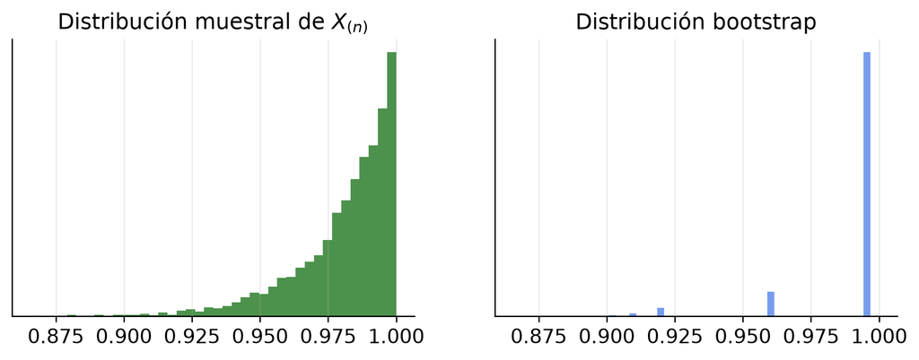

Distribución muestral verdadera del máximo de una uniforme frente a su distribución bootstrap. El bootstrap concentra el 63 % de su masa en el valor observado.

```python
n, theta = 50, 1.0
x = rng.uniform(0, theta, n)
verdadera = np.array([rng.uniform(0, theta, n).max() for _ in range(4000)])
boot = bootstrap(x, np.max, 4000)
print("P(theta* = theta_hat) = %.3f   1 - (1-1/n)^n = %.3f" % (np.mean(boot == x.max()), 1 - (1 - 1/n)**n))
fig, ax = plt.subplots(1, 2, figsize=(9.5, 3), sharex=True)
ax[0].hist(verdadera, bins=40, color=MYGREEN, alpha=.7); ax[0].set_title("Distribución muestral de $X_{(n)}$")
ax[1].hist(boot, bins=40, color=MYBLUE, alpha=.7); ax[1].set_title("Distribución bootstrap")
for a in ax: a.set_yticks([])
plt.show()
```

Otras situaciones en que el bootstrap ordinario falla o requiere modificaciones son las siguientes. Estadísticos no suaves, como el máximo, el mínimo o cuantiles extremos. Muestras muy pequeñas, donde $\hat F_n$ es una mala aproximación de $F$. Datos dependientes, como series de tiempo o datos agrupados, donde remuestrear observaciones individuales destruye la dependencia; la solución es remuestrear bloques contiguos o grupos completos. Y datos de un diseño muestral complejo, con estratos y conglomerados, donde el remuestreo debe respetar el diseño. Este último caso reaparece en la tarea, donde los cuidadores están agrupados en centros de salud.

# 8 El bootstrap dentro del flujo de preprocesamiento

La regla de la unidad 3 establece que todo paso que estima parámetros a partir de los datos es parte del modelo. La consecuencia para el bootstrap es directa. Si el estadístico $T_n$ incluye pasos de preprocesamiento (imputación, selección de variables, ajuste de un modelo), esos pasos deben ejecutarse de nuevo dentro de cada réplica bootstrap. Remuestrear sólo el último paso subestima la varianza, porque trata como fijas decisiones que en realidad dependen de los datos. La estabilidad de la selección del Lasso, medida por la frecuencia con que cada variable se selecciona sobre remuestreos, es un ejemplo de esta regla aplicada correctamente.

# 9 Síntesis esquemática

El bootstrap sustituye $F$ por $\hat F_n$ y aproxima por simulación la varianza de cualquier estadístico. El algoritmo es remuestrear con reemplazo, recalcular y repetir. Los tres intervalos, normal, pivotal y de percentiles, son aproximados y de precisión comparable; su cobertura real se degrada con $n$ pequeño y hay que verificarla cuando sea posible. El bootstrap paramétrico remuestrea del modelo ajustado. El método falla para estadísticos no suaves como el máximo y requiere remuestrear bloques o grupos cuando los datos son dependientes. Todo paso del análisis que dependa de los datos debe repetirse dentro de cada réplica.